# Race-Gen: Multilevel mediation model

Hannah

4/21/2020

## Theoretical mediation model

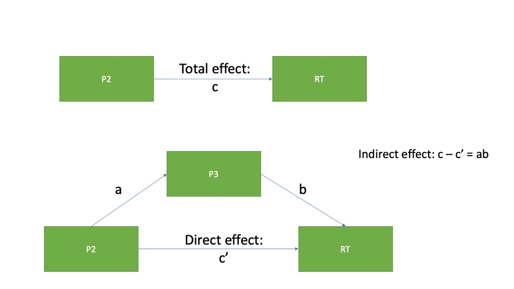

Approach:  
- Model 1 estimates *c* path (total effect), Model 2 estimates *a* path, Model 3 estimates *b* and *c’* path  
- Indirect effect calculated by multiplying *ab*  
- Asymmetric confidence limits approach used to calculate confidence interval estimate of indirect effect  
- Done separately for each task

## Model 1: X -> Y

### P2 amplitude predicting RT

#### P2 amplitude is separated into within and between person effects

**Between person effect:**  
P2.mean = subject mean (separate subject mean for each electrode)  
**Within person effect:**  
P2.meancent = trial level P2 amplitude centered around subject/electrode mean  
**DV:**  
RT

Incorrect trials and trials with +/- 75 uV artifacts are excluded. Subjects with < 50% trials accepted are excluded.

Total sample n = 66 Included n = 63 (33 black, 30 white)

```
## lmer(formula = RT ~ P2.mean + P2.meancent + (1 | Subject), data = racedat)
```

```
##  Groups   Name        Std.Dev.
##  Subject  (Intercept) 49.171
##  Residual             77.565
```

|  | Estimate | Std. Error | df | t value | Pr(>\|t\|) |
| --- | --- | --- | --- | --- | --- |
| (Intercept) | 435.299 | 6.224 | 63.012 | 69.940 | 0.000 |
| P2.mean | -0.014 | 0.200 | 123573.175 | -0.072 | 0.943 |
| P2.meancent | -0.331 | 0.025 | 142780.017 | -13.155 | 0.000 |

## Model 2: X -> M

### P2 amplitude predicting P3 latency

#### P2 amplitude is separated into within and between person effects

**Between person effect:**  
P2.mean = subject mean (separate subject mean for each electrode)  
**Within person effect:**  
P2.meancent = trial level P2 amplitude centered around subject/electrode mean  
**DV:**  
PeakLat = P3 latency, not filtered

Incorrect trials and trials with +/- 75 uV artifacts are excluded. Subjects with < 50% trials accepted are excluded.

Total sample n = 66 Included n = 63 (33 black, 30 white)

```
## lmer(formula = PeakLat ~ P2.mean + P2.meancent + (1 | Subject),
##     data = racedat)
```

```
##  Groups   Name        Std.Dev.
##  Subject  (Intercept) 53.412
##  Residual             68.366
```

|  | Estimate | Std. Error | df | t value | Pr(>\|t\|) |
| --- | --- | --- | --- | --- | --- |
| (Intercept) | 497.623 | 6.750 | 62.671 | 73.720 | 0 |
| P2.mean | -1.350 | 0.178 | 133093.154 | -7.583 | 0 |
| P2.meancent | -0.152 | 0.022 | 141783.007 | -6.815 | 0 |

## Model 3: X + M -> Y

### P2 amplitude and P3 latency predicting RT

#### P2 amplitude and P3 latency both separated into within and between person effects

**Between person effects:**  
P2.mean = subject mean (separate subject mean for each electrode) P3lat.mean = subject mean (separate subject mean for each electrode) , not filtered  
**Within person effects:**  
P2.meancent = trial level P2 amplitude centered around subject/electrode mean  
P3lat.meancent = trial level P3 amplitude centered around subject/electrode mean, not filtered  
**DV:**  
RT

Incorrect trials and trials with +/- 75 uV artifacts are excluded. Subjects with < 50% trials accepted are excluded.

Total sample n = 66 Included n = 63 (33 black, 30 white)

```
## lmer(formula = RT ~ P2.mean + P3lat.mean + P2.meancent + P3lat.meancent +
##     (1 | Subject), data = racedat)
```

```
##  Groups   Name        Std.Dev.
##  Subject  (Intercept) 48.535
##  Residual             75.963
```

|  | Estimate | Std. Error | df | t value | Pr(>\|t\|) |
| --- | --- | --- | --- | --- | --- |
| (Intercept) | 421.333 | 16.366 | 1507.127 | 25.745 | 0.000 |
| P2.mean | 0.024 | 0.202 | 116277.369 | 0.119 | 0.905 |
| P3lat.mean | 0.028 | 0.030 | 11549.821 | 0.921 | 0.357 |
| P2.meancent | -0.290 | 0.025 | 141779.515 | -11.741 | 0.000 |
| P3lat.meancent | 0.238 | 0.003 | 141779.515 | 80.400 | 0.000 |

## Calculate indirect effect

**Between person effects:**  
*a* = -1.35, *se* = 0.178  
*b* = 0.028, *se* = 0.03  
*c* = -0.014, *se* = 0.2  
*c’* = 0.024, *se* = 0.202  
*ab* = -0.038

**Within person effects:**  
*a* = -0.152, *se* = 0.022  
*b* = 0.238, *se* = 0.003  
*c* = -0.331, *se* = 0.025  
*c’* = -0.29, *se* = 0.025  
*ab* = -0.036

## Calculate confidence interval of estimate of indirect effect

First, calculate Sobel standard error:

$\sigma_{ab} = \sqrt{a^2\sigma_{b}^2 + b^2\sigma_{a}^2}$,  
where $\sigma_{a}$ and $\sigma_{b}$ are the standard errors of paths *a* and *b*.

Then, use the asymmetric confidence limits approach with the empirical-M critical values to get 95% CIs:

*Upper Limit* = *ab* + *(C.V. Upper)*($\sigma_{ab}$)

*Lower Limit* = *ab* + *(C.V. Lower)*($\sigma_{ab}$)

The confidence intervals are calculated in RMediation using the empirical-M approach (also called distribution of products approach).

**Between person indirect effect:** Indirect effect = -0.038 [-0.122, 0.043]

**Within person indirect effect:** Indirect effect = -0.036 [-0.047, -0.026]

## Gender categorization task

## Model 1: X -> Y

### P2 amplitude predicting RT

#### P2 amplitude is separated into within and between person effects

**Between person effect:**  
P2.mean = subject mean (separate subject mean for each electrode)  
**Within person effect:**  
P2.meancent = trial level P2 amplitude centered around subject/electrode mean  
**DV:**  
RT

Incorrect trials and trials with +/- 75 uV artifacts are excluded. Subjects with < 50% trials accepted are excluded.

Total sample n = 66 Included n = 63 (32 black, 31 white)

```
## lmer(formula = RT ~ P2.mean + P2.meancent + (1 | Subject), data = gendat)
```

```
##  Groups   Name        Std.Dev.
##  Subject  (Intercept) 41.770
##  Residual             84.591
```

|  | Estimate | Std. Error | df | t value | Pr(>\|t\|) |
| --- | --- | --- | --- | --- | --- |
| (Intercept) | 457.594 | 5.305 | 63.76 | 86.254 | 0.000 |
| P2.mean | -0.015 | 0.218 | 100333.01 | -0.066 | 0.947 |
| P2.meancent | -0.323 | 0.028 | 137404.02 | -11.569 | 0.000 |

## Model 2: X -> M

### P2 amplitude predicting P3 latency

#### P2 amplitude is separated into within and between person effects

**Between person effect:**  
P2.mean = subject mean (separate subject mean for each electrode)  
**Within person effect:**  
P2.meancent = trial level P2 amplitude centered around subject/electrode mean  
**DV:**  
PeakLat = P3 latency, not filtered

Incorrect trials and trials with +/- 75 uV artifacts are excluded. Subjects with < 50% trials accepted are excluded.

Total sample n = 66 Included n = 63 (32 black, 31 white)

```
## lmer(formula = PeakLat ~ P2.mean + P2.meancent + (1 | Subject),
##     data = gendat)
```

```
##  Groups   Name        Std.Dev.
##  Subject  (Intercept) 52.738
##  Residual             67.761
```

|  | Estimate | Std. Error | df | t value | Pr(>\|t\|) |
| --- | --- | --- | --- | --- | --- |
| (Intercept) | 514.645 | 6.666 | 62.724 | 77.199 | 0 |
| P2.mean | -1.379 | 0.177 | 128673.750 | -7.797 | 0 |
| P2.meancent | -0.123 | 0.022 | 135926.012 | -5.451 | 0 |

## Model 3: X + M -> Y

### P2 amplitude and P3 latency predicting RT

#### P2 amplitude and P3 latency both separated into within and between person effects

**Between person effects:**  
P2.mean = subject mean (separate subject mean for each electrode) P3lat.mean = subject mean (separate subject mean for each electrode) , not filtered  
**Within person effects:**  
P2.meancent = trial level P2 amplitude centered around subject/electrode mean  
P3lat.meancent = trial level P3 amplitude centered around subject/electrode mean, not filtered  
**DV:**  
RT

Incorrect trials and trials with +/- 75 uV artifacts are excluded. Subjects with < 50% trials accepted are excluded.

Total sample n = 66 Included n = 63 (32 black, 31 white)

```
## lmer(formula = RT ~ P2.mean + P3lat.mean + P2.meancent + P3lat.meancent +
##     (1 | Subject), data = gendat)
```

```
##  Groups   Name        Std.Dev.
##  Subject  (Intercept) 40.877
##  Residual             82.834
```

|  | Estimate | Std. Error | df | t value | Pr(>\|t\|) |
| --- | --- | --- | --- | --- | --- |
| (Intercept) | 437.780 | 17.114 | 1726.237 | 25.581 | 0.000 |
| P2.mean | 0.038 | 0.220 | 78624.425 | 0.172 | 0.864 |
| P3lat.mean | 0.039 | 0.032 | 5383.498 | 1.215 | 0.224 |
| P2.meancent | -0.292 | 0.027 | 135921.688 | -10.616 | 0.000 |
| P3lat.meancent | 0.259 | 0.003 | 135921.688 | 77.854 | 0.000 |

## Calculate indirect effect

**Between person effects:**  
*a* = -1.379, *se* = 0.177  
*b* = 0.039, *se* = 0.032  
*c* = -0.015, *se* = 0.218  
*c’* = 0.038, *se* = 0.22  
*ab* = -0.053

**Within person effects:**  
*a* = -0.123, *se* = 0.022  
*b* = 0.259, *se* = 0.003  
*c* = -0.323, *se* = 0.028  
*c’* = -0.292, *se* = 0.027  
*ab* = -0.032

## Calculate confidence interval of estimate of indirect effect

First, calculate Sobel standard error:

$\sigma_{ab} = \sqrt{a^2\sigma_{b}^2 + b^2\sigma_{a}^2}$,  
where $\sigma_{a}$ and $\sigma_{b}$ are the standard errors of paths *a* and *b*.

Then, use the asymmetric confidence limits approach with the empirical-M critical values to get 95% CIs:

*Upper Limit* = *ab* + *(C.V. Upper)*($\sigma_{ab}$)

*Lower Limit* = *ab* + *(C.V. Lower)*($\sigma_{ab}$)

The confidence intervals are calculated in RMediation using the empirical-M approach (also called distribution of products approach).

**Between person indirect effect:** Indirect effect = -0.053 [-0.143, 0.032]

**Within person indirect effect:** Indirect effect = -0.032 [-0.043, -0.02]